# Red Wine Quality EDA by Chip Reeves

# Multivariate Plots Section

Based on the bivariate plots, I selected 3 variables for further analysis: citric acid, alcohol, and volatile acidity. I started by producing three scatterplots colored by wine quality.

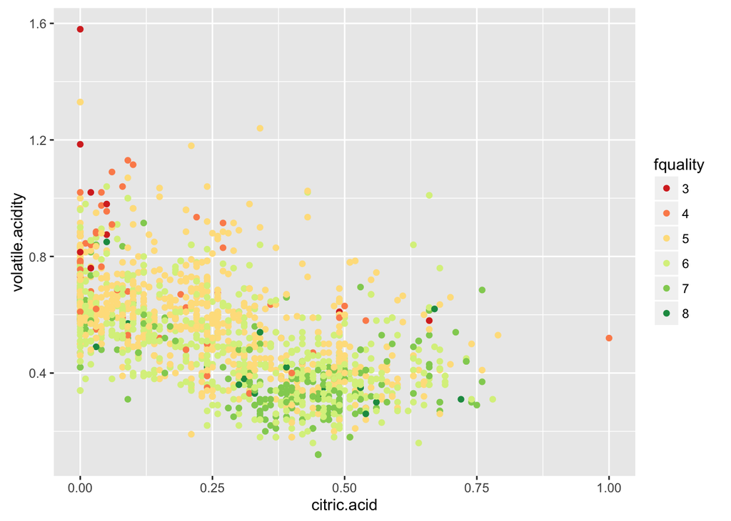

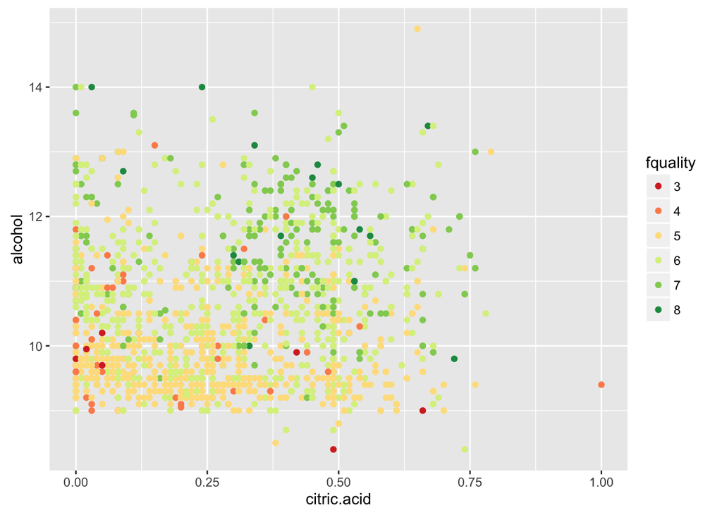

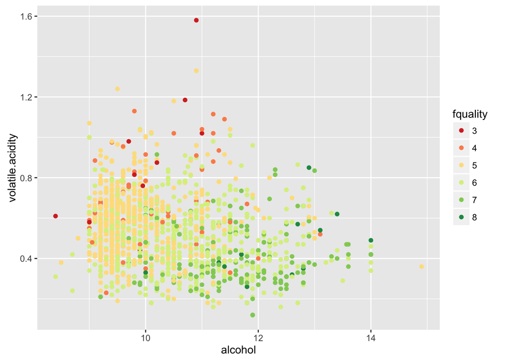

These graphs were not particularly insightful, possibilty due to the large number of average wines. So, I decided to split the data to examine the characteristics of only the high quality wines (quality ratings 7-8) versus lower quality wines (quality ratings 3-4).

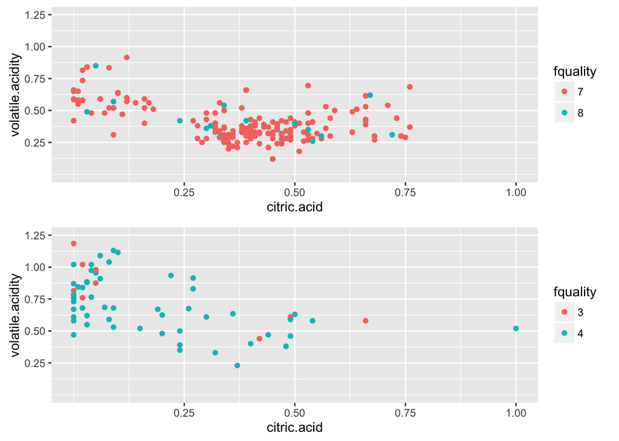

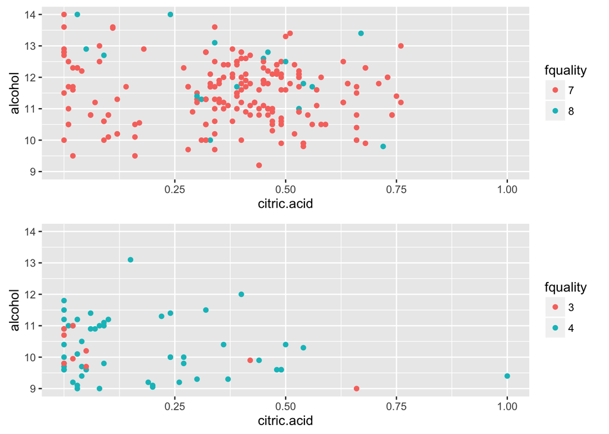

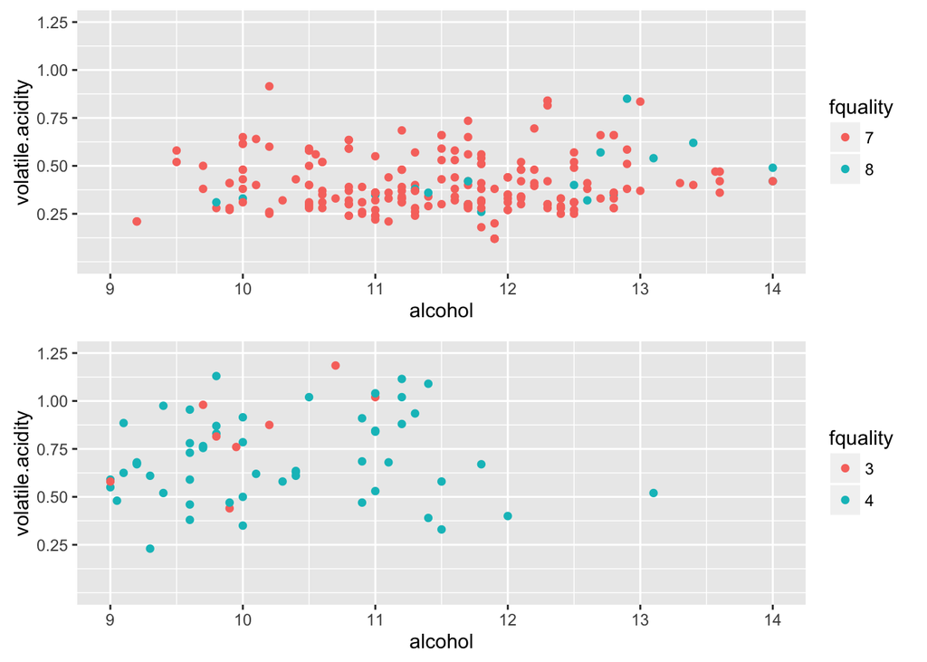

This actually was more helpful than expected. We actually start to see some separation of the values on good and poor wines. The lower quality wines in the sample generally have lower alcohol content (<11%) and higher volatile acidity (>.5 g/dm^3) than the higher quality wines. However, the alcohol content for higher quality wines appears to be more evenly dispursed. The lower quality wines also have a lower citric acid content (<.25 g/dm^3) coupled with the lower alcohol content and higher volatile acidity.

Lastly, I attempted to produce a linear model of wine quality using the three variables mentioned.

```
##
## Calls:
## m1: lm(formula = quality ~ volatile.acidity, data = rw)
## m2: lm(formula = quality ~ volatile.acidity + citric.acid, data = rw)
## m3: lm(formula = quality ~ volatile.acidity + citric.acid + alcohol,
##     data = rw)
## m4: lm(formula = quality ~ volatile.acidity + citric.acid + alcohol +
##     log.sulphates, data = rw)
##
## ================================================================
##                        m1         m2         m3         m4
## ----------------------------------------------------------------
##   (Intercept)        6.566***   6.529***   3.055***   3.444***
##                     (0.058)    (0.089)    (0.194)    (0.196)
##   volatile.acidity  -1.761***  -1.723***  -1.343***  -1.217***
##                     (0.104)    (0.125)    (0.114)    (0.112)
##   citric.acid                   0.063      0.068     -0.113
##                                (0.115)    (0.103)    (0.103)
##   alcohol                                  0.314***   0.303***
##                                           (0.016)    (0.016)
##   log.sulphates                                       1.518***
##                                                      (0.181)
## ----------------------------------------------------------------
##   R-squared             0.153      0.153      0.317      0.346
##   adj. R-squared        0.152      0.152      0.316      0.344
##   sigma                 0.744      0.744      0.668      0.654
##   F                   287.444    143.812    246.976    210.808
##   p                     0.000      0.000      0.000      0.000
##   Log-likelihood    -1794.312  -1794.160  -1621.596  -1587.153
##   Deviance            883.198    883.030    711.603    681.597
##   AIC                3594.624   3596.320   3253.192   3186.306
##   BIC                3610.756   3617.828   3280.078   3218.569
##   N                  1599       1599       1599       1599
## ================================================================
```

The final model using volatile acidity, citric acid, alcohol, and sulphates (log10) only had an R-sq of .346. This indicates the final model has very little predictive power. The process started looking at quality as a function of volatile acidity. Adding citric acid had absolutely no impact to the model. It could be dropped or perhaps replaced volatile acidity. Adding alcohol produced a nice bump in R-sq from .153 to .317. However, adding the log10 of sulfates only produced a small improvement in the model.

# Multivariate Analysis

### Talk about some of the relationships you observed in this part of the investigation. Were there features that strengthened each other in terms of looking at your feature(s) of interest?

I initially produced single plots comparing alcohol, citric acid, and volatile acidity, all colored by the quality. Due to the large number of “average” quality wines, it was diffcult to gain many visual cues. I decided to focus on the characteristics of higher quality wines (7-8) compared with lower quality (3-4). I subset the data accordingly and produced pairs of graphs with similar scales.

As mentioned earlier, the lower quality wines in the sample have lower alcohol content and higher volatile acidity than the higher quality wines. However, the alcohol content for higher quality wines appears to be more evently dispursed. The lower quality wines also have a lower citric acid content coupled with the lower alcohol content and higher volatile acidity.

### Were there any interesting or surprising interactions between features?

It was interesting to see the *lack* of interaction between alcohol and citric acid on the good wines. Good wines exist across most points in this plot.

### OPTIONAL: Did you create any models with your dataset? Discuss the strengths and limitations of your model.

Again, as previously mentioned. I attempted a linear model to attempt to predict wine quality. A model using volatile acidity, citric acid, alcohol, and sulphates (log10) only had an R-sq of .346. Very little predictive power.

# Final Plots and Summary

### Plot One

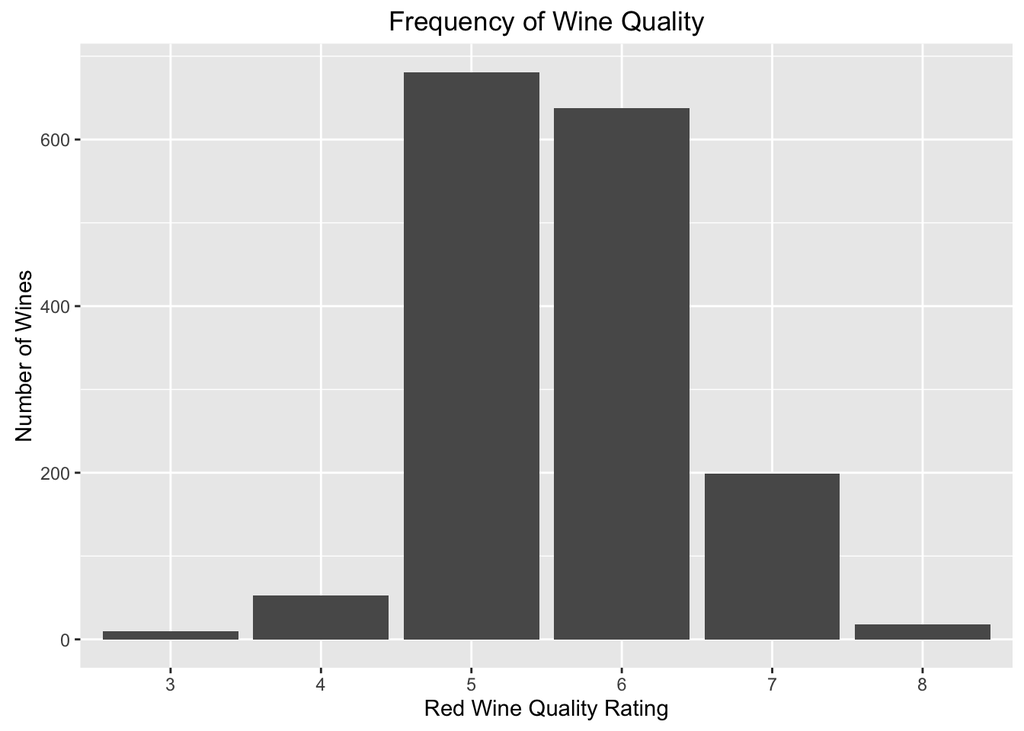

### Description One

The vast majority of wines are average quality. It may be difficult to draw conclusions from such a narrow data set. This may also reflect some issues with the methodology if only three raters were used for each tasting. If one rater believes the wine is a higher quality and one rater scores it a lower quality, those will cancel each other out, leaving only the middle (median) rating. Using more wine experts on each sample would help to counteract this possibility.

### Plot Two

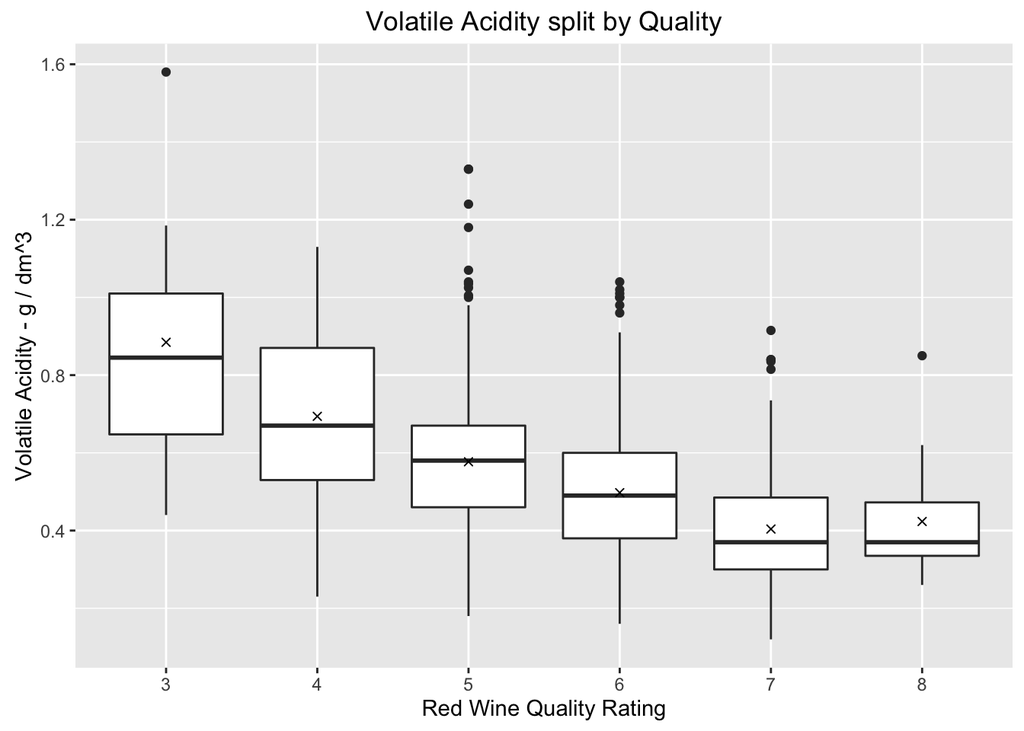

### Description Two

This plot shows a nice inverse relationship between volatile acidity and quality. Both the median value and distribution of acidity decrease as quality increases.

### Plot Three

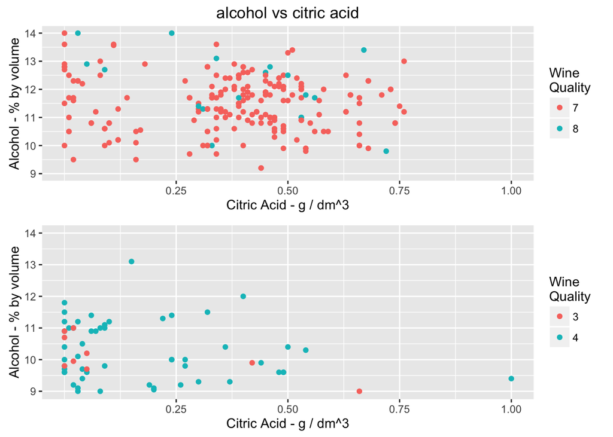

### Description Three

For the lower quality wines, there are few redemptive properties. They are lower in citric acid, so they don’t have a taste as fresh and fruity as higher quality wines. But they also have a lower alcohol content. It would take more of this unpleasant beverage to achieve the desired level of “relaxation”.

For the higher quality wines, the plot of citric acid and alcohol is more evenly distributed. From a statistical point of view, this indicates little relationship between these variables at these quality levels. Perhaps other variables have stronger relationships with higher quality wines. However, from a practical standpoint, it could also mean that there are pleasant wines across many points in these scales. Personal preference may impact quality ratings.

# Reflection

The wine quality data set looked at the chemical properties of 1599 red wines. I produced univariate, bivariate, and multivariate plots to attempt to find the variables with the highest impact on wine quality.

One area of frustration was that nothing really “jumped out”. Many of the plots did not indicate any relationship with wine quality. It was hard to feel confident in choosing any direction for further analysis. It was also difficult to draw many conclusions from this data set since over 80% of the wines are “average” quality. Any fitted models would likely have limited predictive power. It was also challenging to model what is really a discrete or categorical variable.

During the mutivariate analysis, I felt most confident in the analysis that split the data into higher and lower quality wines. That unconventional decision finally seemed to produce something interesting. The obvious drawback to this approach is that is discards most of the data. Splitting the data this way could be useful for future analysis.

As for additional future analysis, modeling a categorical dependent variable seems to be a better approach. Additional research would be needed to determine how to implement this in R. This would also be a good opportunity to consider addtional variables in the model to attempt to improve predictive power.